# STT 3851: CH 3 and 4 Exam

Jessie Baron

4/16/2020

1. Using the college football data, predict the team’s Zsagarin score via the following steps.
1. Consider the following potential predictors: Fr5Star, Fr4Star, Fravg, So5Star, So4Star, Soavg, Jr5Star, Jr4Star, Jravg, Sr5Star, Sr4Star, Sravg, Rssr5Star, Rssr4Star, Rssravg. Which of these predictors (by itself) has the strongest relationship with the response variable? Justify your answer.

```r
library(readxl)

cfb <- read_excel("CFB2018completeISLR.xlsx")

library(dplyr)
glimpse(cfb)
```

```
## Rows: 857
## Columns: 46
## $ Team            <chr> "Alabama", "Arizona", "Arizona State", "Arkansas", "A…
## $ Year            <dbl> 2007, 2007, 2007, 2007, 2007, 2007, 2007, 2007, 2007,…
## $ Sagarin         <dbl> 79.26, 76.40, 84.35, 81.39, 84.42, 58.75, 81.61, 79.3…
## $ Zsagarin        <dbl> 0.2016658, -0.1280565, 0.7884793, 0.4472283, 0.796549…
## $ FrNbrRecruits   <dbl> 25, 18, 24, 27, 30, 29, 18, 26, 23, 23, 28, 29, 21, 2…
## $ Fr5star         <dbl> 0, 0, 0, 0, 0, 0, 0, 0, 0, 0, 1, 0, 0, 4, 0, 0, 0, 2,…
## $ Fr4star         <dbl> 10, 4, 2, 4, 13, 1, 2, 5, 0, 8, 2, 1, 0, 16, 7, 12, 8…
## $ Fr3star         <dbl> 12, 9, 13, 17, 15, 12, 11, 18, 6, 12, 14, 5, 4, 7, 10…
## $ Fravg           <dbl> 3.28, 2.72, 2.63, 2.93, 3.37, 2.34, 2.83, 3.00, 2.26,…
## $ Frpoints        <chr> "1789", "792", "783", "1083", "2013", "274", "756", "…
## $ Sonbrrecruits   <dbl> 23, 25, 24, 26, 25, 29, 20, 20, 20, 20, 23, 23, 26, 2…
## $ So5star         <dbl> 2, 1, 0, 1, 1, 0, 0, 0, 0, 2, 0, 0, 0, 4, 2, 2, 0, 0,…
## $ So4star         <dbl> 10, 6, 5, 4, 14, 0, 2, 9, 0, 6, 0, 0, 1, 17, 18, 14, …
```

[output cut: 33 more lines]

```r
basemodel <- lm(Zsagarin ~ Fr5star + Fr4star + Fravg + So5star + So4star + Soavg + Jr5star + Jr4star + Jravg + Sr5star + Sr4star + Sravg + Rssr5star + Rssr4star + Rssravg, data = cfb)
summary(basemodel)
```

```
##
## Call:
## lm(formula = Zsagarin ~ Fr5star + Fr4star + Fravg + So5star +
##     So4star + Soavg + Jr5star + Jr4star + Jravg + Sr5star + Sr4star +
##     Sravg + Rssr5star + Rssr4star + Rssravg, data = cfb)
##
## Residuals:
##      Min       1Q   Median       3Q      Max
## -2.35945 -0.54236 -0.01994  0.56249  2.30314
##
## Coefficients:
##               Estimate Std. Error t value Pr(>|t|)
## (Intercept) -3.5147532  0.4806767  -7.312 6.13e-13 ***
## Fr5star      0.0727353  0.0377268   1.928   0.0542 .
## Fr4star     -0.0082470  0.0135454  -0.609   0.5428
## Fravg        0.7458074  0.1729294   4.313 1.80e-05 ***
## So5star      0.0819158  0.0400146   2.047   0.0410 *
## So4star     -0.0007926  0.0138777  -0.057   0.9545
## Soavg        0.1614337  0.1857126   0.869   0.3849
## Jr5star     -0.0023370  0.0411759  -0.057   0.9548
## Jr4star      0.0180814  0.0141197   1.281   0.2007
## Jravg        0.1471709  0.1934286   0.761   0.4470
## Sr5star     -0.0735255  0.0404876  -1.816   0.0697 .
## Sr4star      0.0110079  0.0141689   0.777   0.4374
## Sravg        0.0246885  0.1843896   0.134   0.8935
## Rssr5star   -0.0497679  0.0408332  -1.219   0.2233
## Rssr4star   -0.0002772  0.0141239  -0.020   0.9843
## Rssravg      0.0587022  0.1675729   0.350   0.7262
## ---
## Signif. codes:  0 '***' 0.001 '**' 0.01 '*' 0.05 '.' 0.1 ' ' 1
##
## Residual standard error: 0.8005 on 841 degrees of freedom
## Multiple R-squared:  0.3501, Adjusted R-squared:  0.3385
## F-statistic:  30.2 on 15 and 841 DF,  p-value: < 2.2e-16
```

Looking at the basemodel above, our strongest predictors in relation to our response variabe, `Zsagarin`, are Freshman Average, Freshman 5 Star, Sophomore 5 Star, and Senior 5 Star. The Freshman Average has the strongest relationship with a p value close to 0, followed by Sophomore 5 Star with a p value of 0.0410. Freshman 5 Star and Senior 5 Star have the lowest siginficance with p values of 0.0542 and 0.0697 respectively.

2. Build a multiple regression model with your predictor from part (a) and at least two other predictors from the set above, so that all three predictors have a statistically significant association with the response.

```r
model1 <- lm(Zsagarin ~ Fravg + So5star, data = cfb)
summary(model1)
```

```
##
## Call:
## lm(formula = Zsagarin ~ Fravg + So5star, data = cfb)
##
## Residuals:
##      Min       1Q   Median       3Q      Max
## -2.46803 -0.54704  0.01166  0.55550  2.45925
##
## Coefficients:
##             Estimate Std. Error t value Pr(>|t|)
## (Intercept) -3.43914    0.21920 -15.690  < 2e-16 ***
## Fravg        1.12561    0.07486  15.035  < 2e-16 ***
## So5star      0.10856    0.03197   3.396 0.000715 ***
## ---
## Signif. codes:  0 '***' 0.001 '**' 0.01 '*' 0.05 '.' 0.1 ' ' 1
##
## Residual standard error: 0.8055 on 854 degrees of freedom
## Multiple R-squared:  0.3317, Adjusted R-squared:  0.3302
## F-statistic:   212 on 2 and 854 DF,  p-value: < 2.2e-16
```

3. Add Conference to your model from part (b). Report on your findings.

```r
model2 <- lm(Zsagarin ~ Fravg + So5star + conference, data = cfb)
summary(model2)
```

```
##
## Call:
## lm(formula = Zsagarin ~ Fravg + So5star + conference, data = cfb)
##
## Residuals:
##      Min       1Q   Median       3Q      Max
## -2.41736 -0.53652 -0.00688  0.57132  2.27134
##
## Coefficients:
##                     Estimate Std. Error t value Pr(>|t|)
## (Intercept)         -3.45942    0.25475 -13.580  < 2e-16 ***
## Fravg                1.10489    0.08423  13.117  < 2e-16 ***
## So5star              0.11321    0.03244   3.490 0.000508 ***
## conferenceBigeast    0.02804    0.10454   0.268 0.788559
## conferencebigten     0.02893    0.09184   0.315 0.752816
## conferencebigtwelve  0.26228    0.09586   2.736 0.006346 **
## conferenceInd       -0.27140    0.24403  -1.112 0.266383
## conferencepacten     0.07747    0.09440   0.821 0.412094
## conferenceSEC        0.12981    0.09350   1.388 0.165403
## ---
## Signif. codes:  0 '***' 0.001 '**' 0.01 '*' 0.05 '.' 0.1 ' ' 1
##
## Residual standard error: 0.8026 on 848 degrees of freedom
## Multiple R-squared:  0.3411, Adjusted R-squared:  0.3349
## F-statistic: 54.88 on 8 and 848 DF,  p-value: < 2.2e-16
```

4. For the model you built in part (b), calculate the Variance Inflation Factor for your predictors and note any cases of significant multicollinearity in the model. If multicollinearity is significant, attempt some remedies and describe your reasoning in doing so. If you do not need to remedy significant multicollinearity, explain why.

```r
library(car)
vif(model1, data = cfb)
```

```
##   Fravg So5star
## 1.44148 1.44148
```

The VIF for Freshman Average and Sophomore 5 Star are both 1.44 suggesting that there is there is no multicolinearity between these predictors and the response variable `Zsagarin`.

5. After modifying your model in part (d), if needed, produce and interpret a set of diagnostic plots for your model. Comment on the plots.

Our model in part (d) did not need to be modified because our values were around 1, so we can proceed with our regression.

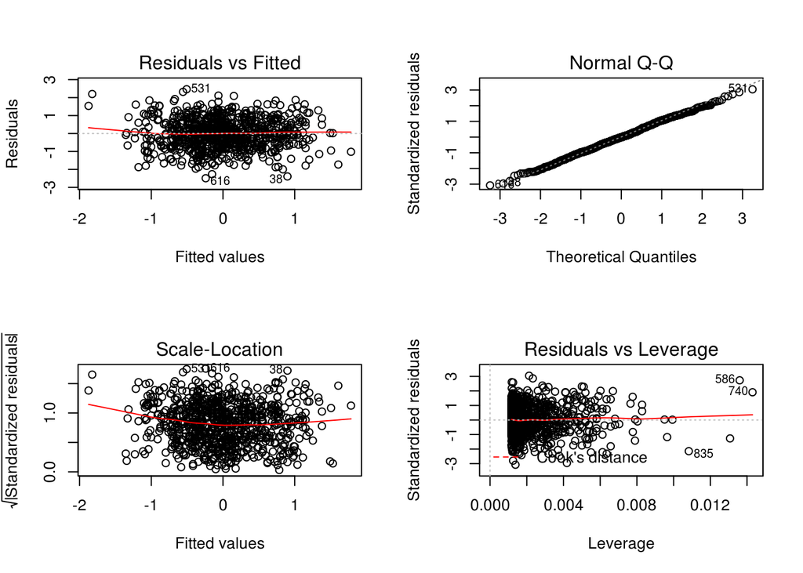

```r
x1 <- lm(cfb$Zsagarin ~ cfb$Fravg)
par(mfrow=c(2,2))
plot(x1)
```

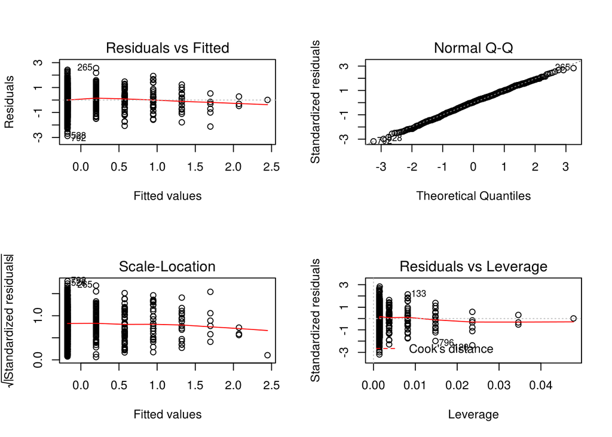

```r
x2 <- lm(cfb$Zsagarin ~ cfb$So5star)
par(mfrow=c(2,2))
plot(x2)
```

2. The Donner party were a group of pioneers that migrated to California from the Midwest in the mid-1800’s. Their story is quite extensive, and tragic in many way (https://en.wikipedia.org/wiki/Donner_Party). The data set provided in donner.xlsx gives information on a set of travelers in the party. Specifically, if the traveler was traveling with an immediate family member (MultiFam = 1 if another immediate family member present), the sex of the traveler (Sex = 1 for Female), and Age. The response variable of interest is whether the traveler survived (Survived = 1 for survival).
1. The data set has 45 observations. Select 30 data points for training the model and 15 points for test data. Clearly show the code that you use to create these sets.

```r
library(readxl)
donner <- read_excel("donner.xlsx")
glimpse(donner)
```

```
## Rows: 45
## Columns: 5
## $ Name     <chr> "Antonio", "Breen Mary", "Breen Patrick", "Burger Charles", …
## $ Multifam <dbl> 0, 1, 1, 0, 0, 0, 1, 1, 1, 1, 1, 1, 0, 1, 1, 1, 1, 1, 1, 1, …
## $ Sex      <dbl> 0, 1, 0, 0, 0, 0, 1, 0, 0, 1, 1, 0, 0, 0, 1, 1, 0, 1, 1, 0, …
## $ Age      <dbl> 23, 40, 40, 30, 28, 40, 45, 62, 65, 45, 25, 28, 28, 23, 22, …
## $ Survived <dbl> 0, 1, 1, 0, 0, 0, 0, 0, 0, 0, 0, 1, 0, 0, 1, 1, 1, 1, 0, 0, …
```

```r
set.seed(1)
train <- sample(45,30, replace = FALSE)
train
```

```
##  [1] 12 17 25 39  9 36 37 26 24  3  8  7 23 13 42 15 21 28 11 29 31  6 30 40 43
## [26] 35  1 34 33 38
```

```r
traindata <- donner[train,]
traindata
```

```
## # A tibble: 30 x 5
##    Name            Multifam   Sex   Age Survived
##    <chr>              <dbl> <dbl> <dbl>    <dbl>
##  1 Eddy William           1     0    28        1
##  2 Foster William         1     0    28        1
##  3 Herron William         0     0    25        1
##  4 Smith James            0     0    25        0
##  5 Donner Jacob           1     0    65        0
##  6 Reed Margaret          1     1    32        1
##  7 Reinhardt Josep        0     0    30        0
##  8 Noah James             0     0    20        1
##  9 Hardkoop Mr            0     0    60        0
## 10 Breen Patrick          1     0    40        1
## # … with 20 more rows
```

```r
testdata <- donner[-train,]
testdata
```

```
## # A tibble: 15 x 5
##    Name            Multifam   Sex   Age Survived
##    <chr>              <dbl> <dbl> <dbl>    <dbl>
##  1 Breen Mary             1     1    40        1
##  2 Burger Charles         0     0    30        0
##  3 Denton John            0     0    28        0
##  4 Donner Tamsen          1     1    45        0
##  5 Fosdick Jay            1     0    23        0
##  6 Foster Sarah           1     1    23        1
##  7 Graves Eleanor         1     1    15        1
##  8 Graves Eliza           1     1    47        0
##  9 Graves Franklin        1     0    57        0
## 10 Graves William         1     0    18        1
## 11 Keseberg Lewis         1     0    32        1
## 12 Murphy Lavin           1     1    50        0
## 13 Spitzer Augustu        0     0    30        0
## 14 Williams Baylis        1     0    24        0
## 15 Williams Eliza         1     1    25        1
```

2. Create a logistic regression model using the training data, and with the three predictors (Multifam, Sex, and Age).

```r
model3 <- glm(Survived ~ Multifam + Sex + Age, family=binomial(link='logit'),data=traindata)
summary(model3)
```

```
##
## Call:
## glm(formula = Survived ~ Multifam + Sex + Age, family = binomial(link = "logit"),
##     data = traindata)
##
## Deviance Residuals:
##     Min       1Q   Median       3Q      Max
## -1.9780  -0.7885  -0.3725   0.8358   1.6246
##
## Coefficients:
##             Estimate Std. Error z value Pr(>|z|)
## (Intercept)  0.72220    1.32729   0.544    0.586
## Multifam     2.12018    1.11821   1.896    0.058 .
## Sex          0.23511    1.18853   0.198    0.843
## Age         -0.06924    0.04326  -1.601    0.109
## ---
## Signif. codes:  0 '***' 0.001 '**' 0.01 '*' 0.05 '.' 0.1 ' ' 1
##
## (Dispersion parameter for binomial family taken to be 1)
##
##     Null deviance: 41.455  on 29  degrees of freedom
## Residual deviance: 32.144  on 26  degrees of freedom
## AIC: 40.144
##
## Number of Fisher Scoring iterations: 4
```

```r
probabilities <- predict(model3, testdata, type = "response")
probabilities
```

```
##         1         2         3         4         5         6         7         8
## 0.5763480 0.2050428 0.2285380 0.4903982 0.7772661 0.8153143 0.8848167 0.4558908
##         9        10        11        12        13        14        15
## 0.2489103 0.8314608 0.6517236 0.4050123 0.2050428 0.7650489 0.7935459
```

```r
library(class)
train.X <- cbind(donner$Multifam, donner$Sex, donner$Age, donner$Survived)[donner$traindata]
test.X <- cbind(donner$Multifam, donner$Sex, donner$Age, donner$Survived)[donner$testdata]
train.classification <- donner$Survived[donner$traindata]
train.classification
```

```
## numeric(0)
```